# Intro to RNA-seq Analysis

Hosted by the IIGB Bioinformatics Core

Brandon Le

Genomics Building 1207G

# About the Core

## IIGB Bioinformatics Core

- Website
- Services
- Workshops
- Office Hour

https://facility.bioinformatics.ucr.edu

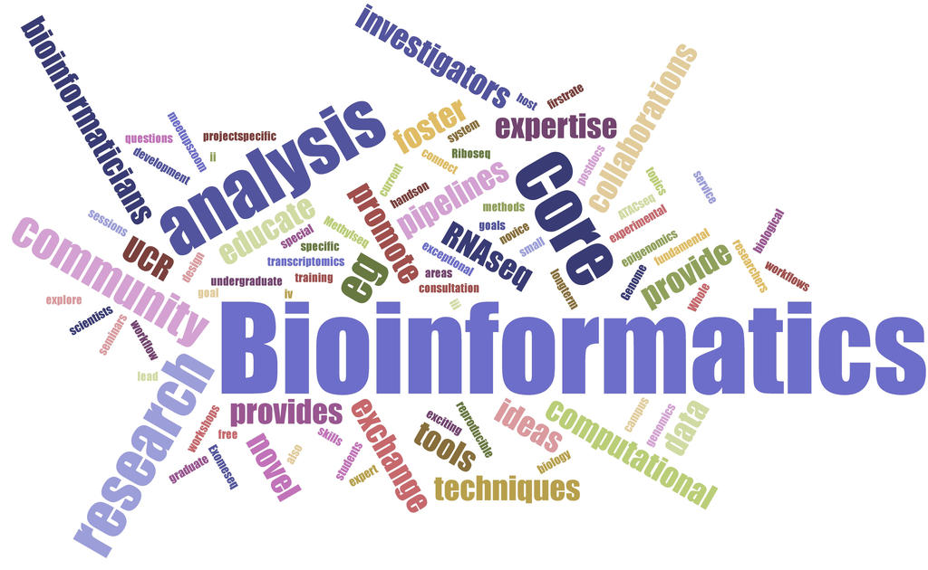

- Data analysis
  - RNA-seq, ChIP-seq
  - scRNA-seq
  - DNA-seq
  - Other
- Project consultations
- Method development
- [Repositories](https://github.com/orgs/bioinformatics-workshop/repositories)
- Past workshops
  - [Intro to Unix](https://github.com/bioinformatics-workshop/Intro-to-Unix)
  - [Intro to R/R-Studio](https://github.com/bioinformatics-workshop/Intro-to-R-RStudio)
  - [Intro to Shell Scripting](https://github.com/bioinformatics-workshop/Intro-to-Shell-Scripting)
- Daily (2-3PM)
- In-person or via Zoom (by appt)
- [Calendly](https://calendly.com/ucr_iigb_bioinfocore)

# Workshop Outline

Workshop dates:

Workshop I: October 18-19, 2023

Workshop II: October 25-26, 2023

**Day One**

- Introduction to RNA-seq
- Data analysis setup
- Data QC
- Sequence alignment

**Day Two**

- Feature quantitation
- Data pre-processing
- Identify DEGs
- Data visualization

# Day One

## What is RNA-seq?

RNA sequencing or **RNA-seq** is one of many methods used for gene expression studies by obtaining a snapshot of the RNA molecules within a biological system.

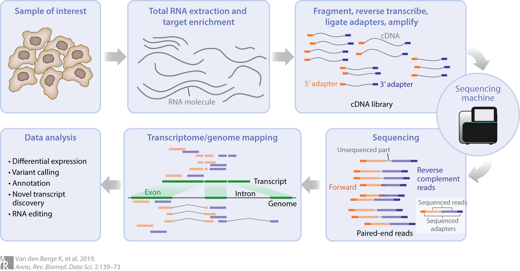

Reference: [Van den Berge et. al (2019) Annu Rev Biomed Data Sci](https://www.annualreviews.org/doi/10.1146/annurev-biodatasci-072018-021255)

## What is RNA-seq?

**Next-generation sequencing (NGS) technologies**

- Short-read based (e.g. Illumina)
  - 35 - 300 bases
- Long-read based (e.g., PacBio, Oxford Nanopore)
  - Several kilobases

**Sequencing resolution**

- Bulk tissue (bulk RNA-seq)
- Laser-capture microdissection (LCM + RNA-seq)
- Single-cell (scRNA-seq)
- Spatial transcriptomics (spatial + scRNA-seq)

## Logging in to the server

You should receive an email with login information if you’ve never had an account on the HPCC. For those with an account already, you can use the same credentials to log into the server.

Open up your terminal program (on your Mac or PC) and at the `$` prompt, enter the following command (change `<USERNAME>` to your account name)

**Note**

On the MacOS, there’s a built-in terminal program `Terminal` (you can see it in your Applications folder within the Utilities sub-folder). For WinOS, you can download and install the `MobaXterm` application [(link)](https://mobaxterm.mobatek.net).

```bash
ssh <USERNAME>@cluster.hpcc.ucr.edu

# example
ssh bioinfo-workshop@cluster.hpcc.ucr.edu
```

If connecting for the first time, you’ll see a prompt (type yes and press ENTER):

```bash
The authenticity of host 'sample.ssh.com' cannot be established.
DSA key fingerprint is 04:48:30:31:b0:f3:5a:9b:01:9d:b3:a7:38:e2:b1:0c.
Are you sure you want to continue connecting (yes/no)?
```

Then you’ll be ask for authentication password and two-factor validation with DUO.

After logging in, create a directory for the workshop.

```bash
mkdir bioinformatics-workshops
```

Now change to the newly-created directory

```bash
cd bioinformatics-workshops
```

## Downloading/Uploading files from the server

There will be times where you would want to see plots or access files generated on the cluster. For easier access, you can use an SFTP program with a GUI that connects to the server and provides direct access to those files.

There are several free GUI applications including [Filezilla](https://filezilla-project.org), [Cyberduck](https://cyberduck.io), [WinSCP](https://winscp.net/eng/download.php).

These applications are available for MacOS, WinOS, and Linux platforms.

Once you have the application installed, start up the program and follow the instructions to connect to a site.

[Click here](https://hpcc.ucr.edu/manuals/hpc_cluster/sharing/#authentication-with-passwordduo) for instructions to connect and authenticate to the cluster using `Filezilla` with password + DUO authentication.

## Setting up the analysis directory

We will clone the GitHub repository for this workshop. The repo is stored at: [GitHub Repo](https://github.com/bioinformatics-workshop/RNA-Seq-Workshop/tree/main)

Cloning the repository will download all the files and directories from GitHub to your server/computer.

Cloning the repository:

```bash
git clone https://github.com/bioinformatics-workshop/RNA-Seq-Workshop.git
```

Once the cloning is complete, we can go into the newly-downloaded workshop repository to run our analyses.

```bash
# change to the workshop directory
cd RNA-Seq-Workshop

# lists directory content
ls
```

The home directory structure for the workshop should look like this:

```bash
├── analysis
├── code
├── genome
├── index
├── log
└── raw
```

**Tip**

Cloning the repository will give you the most up-to-date files. To get the latest updates of the repository later on, you don’t need to clone again. Instead, you can `pull` the updates from GitHub to your server/computer. Make sure you are in the home directory of the workshop before running the command.

```bash
git pull
```

## Create conda environment

We will create a conda environment containing bioinformatics software packages not readily available on the cluster for data processing and analysis. This conda environment includes special R packages (e.g., EnhancedVolcano) and software (e.g., multiqc).

To create the conda environment:

```bash
sbatch code/create-conda-env.sh
```

**Note**: *This step can take anywhere from 25-45 minutes. However, it’s running in the background so we can come back to it later.*

To make sure the conda environment was created successfully, we can activate the conda environment:

```bash
conda activate DEG-analysis
```

You should now see the environment `(DEG-analysis)` next to your `$` prompt.

```bash
(DEG-analysis) $
```

**Tip**

To get out of the conda environment, type:

```bash
conda deactivate
```

The environment name in parentheses should now disappear.

## Submitting jobs on the cluster

For this workshop, we will submit jobs to the cluster (to run in the background).

Example job submission:

```bash
sbatch code/multiqc.sh
```

The submitted job will have a six-digit JOBID. To check on the status of your submitted job(s),

```bash
# Show all jobs from USER
squeue -u <USERNAME>

# Show specific job with JOBID
scontrol show job <JOBID>
```

To cancel a submitted job, use the JOBID.

```bash
# To delete a single job
scancel -i <JOBID>
scancel <JOBID>

# To delete all jobs for a user
scancel -u <USERNAME>
```

**Tip**

All submitted jobs will generate a log file (stored in the `log` folder) containing the JOBNAME_JOBID.log

- JOBNAME (e.g., fastqc, trim_galore)

You can take a look at the log file to see standard output/errors from running the script.

## Analysis Toolkit

| Program | Type | Software | Reference | Misc |
| --- | --- | --- | --- | --- |
| Fastqc | QC | [Software](https://www.bioinformatics.babraham.ac.uk/projects/fastqc/) | [Ref](https://www.bioinformatics.babraham.ac.uk/projects/fastqc/) |  |
| Trim_galore | QC | [Software](https://www.bioinformatics.babraham.ac.uk/projects/trim_galore/) | [Ref](https://zenodo.org/records/7598955) |  |
| Multiqc | QC | [Software](https://multiqc.info) | [Ref](https://academic.oup.com/bioinformatics/article/32/19/3047/2196507) | [Manual](https://multiqc.info/docs/) |
| STAR | Alignment | [Software](https://github.com/alexdobin/STAR/releases) | [Ref](https://academic.oup.com/bioinformatics/article/29/1/15/272537) | [Manual](https://github.com/alexdobin/STAR/blob/master/doc/STARmanual.pdf) |
| FeatureCounts | Quantification | [Software](https://sourceforge.net/projects/subread/files/subread-2.0.6/) | [Ref](https://academic.oup.com/bioinformatics/article/30/7/923/232889) |  |
| DESeq2 | Differential Expression | [Software](https://www.bioconductor.org/packages/release/bioc/html/DESeq2.html) | [Ref](https://genomebiology.biomedcentral.com/articles/10.1186/s13059-014-0550-8) | [Guide](https://bioconductor.org/packages/devel/bioc/vignettes/DESeq2/inst/doc/DESeq2.html) |
| IGV | Visualization | [Software](https://igv.org/doc/desktop/) | [Ref](https://academic.oup.com/bib/article/14/2/178/208453) | [Web App](https://igv.org/app/) |
| R | Other | [Software](https://cran.r-project.org) | [Ref](https://www.R-project) |  |
| Tidyverse | Other | [Software](https://www.tidyverse.org) | [Ref](https://joss.theoj.org/papers/10.21105/joss.01686) |  |
| EnhancedVolcano | Other | [Software](https://bioconductor.org/packages/release/bioc/html/EnhancedVolcano.html) | [Ref](https://github.com/kevinblighe/EnhancedVolcano) |  |

## Sample Dataset Demo

| Category | Description |
| --- | --- |
| **BioProject** | PRJNA950346 |
| **GEO Series** | GSE228555 |
| **Title** | Transcriptome expression of WT and mir163 mutant |
| **Organism** | Arabidopsis thaliana |
| **Ecotype** | Col-0 |
| **Genotype** | WT, miR163 mutant |
| **Replicates** | 3 |
| **Tissue** | Seedlings |
| **Library kit** | NEBNext® Ultra™ RNA Library Prep Kit for Illumina (non-stranded) |
| **Sequencing** | Illumina paired-end 150bp |

## Workflow Outline

- Create metadata
- QC using `Fastqc` and `trim_galore`
- Genome indexing for `STAR` aligner
- Sequence alignment with `STAR`
- Gene quantification using `featureCounts`
- Differential expression analysis with `DESeq2`
- Data visualization in IGV

## Data Preparation - Create metadata

Generate a `metadata.csv` file containing information about the dataset. The metadata will be used for processing and differential expression analysis.

Metadata Header

```bash
srr_id
ecotype
genotype
treatment
tissue
biorep
samplename
fq1
fq2
```

Description

```bash
SRR ID from the SRA run
Col-0
WT, miR163_mut
7-day-old plants
seedlings
1,2,3
wt_1,wt_2,wt_3,mir163_1,mir163_2, mir163_3
raw/SRRxxxx_1.fastq.gz
raw/SRRxxxx_2.fastq.gz
```

**Note**

An extensive metadata file describes the samples in detail. However, the minimum metadata file should contain the following:

- samplename (sometime it’s the same name as the fastq file),
- condition/treatment/genotype
- fq1/fq2

Other metadata info can include:

- time point
- technical replicate
- sequencing batch
- library kits
- metadata.csv
- metadata_sub1M.csv

This file contains the metadata for the full dataset

```bash
srr_id,ecotype,genotype,treatment,tissue,biorep,samplename,fq1,fq2
SRR24016000,Col-0,miR163_mut,7-day-old seedlings without treatment,seedlings,1,mir163_1,raw/SRR24016000_1.fastq.gz,raw/SRR24016000_2.fastq.gz
SRR24016001,Col-0,miR163_mut,7-day-old seedlings without treatment,seedlings,2,mir163_2,raw/SRR24016001_1.fastq.gz,raw/SRR24016001_2.fastq.gz
SRR24016002,Col-0,miR163_mut,7-day-old seedlings without treatment,seedlings,3,mir163_3,raw/SRR24016002_1.fastq.gz,raw/SRR24016002_2.fastq.gz
SRR24016003,Col-0,wt,7-day-old seedlings without treatment,seedlings,1,wt_1,raw/SRR24016003_1.fastq.gz,raw/SRR24016003_2.fastq.gz
SRR24016004,Col-0,wt,7-day-old seedlings without treatment,seedlings,2,wt_2,raw/SRR24016004_1.fastq.gz,raw/SRR24016004_2.fastq.gz
SRR24016005,Col-0,wt,7-day-old seedlings without treatment,seedlings,3,wt_3,raw/SRR24016005_1.fastq.gz,raw/SRR24016005_2.fastq.gz
```

This file contains the metadata referencing the 1M sub-sampled dataset

```bash
srr_id,ecotype,genotype,treatment,tissue,biorep,samplename,fq1,fq2
SRR24016000_sub1M,Col-0,miR163_mut,7-day-old seedlings without treatment,seedlings,1,mir163_1,raw/SRR24016000_sub1M_1.fastq.gz,raw/SRR24016000_sub1M_2.fastq.gz
SRR24016001_sub1M,Col-0,miR163_mut,7-day-old seedlings without treatment,seedlings,2,mir163_2,raw/SRR24016001_sub1M_1.fastq.gz,raw/SRR24016001_sub1M_2.fastq.gz
SRR24016002_sub1M,Col-0,miR163_mut,7-day-old seedlings without treatment,seedlings,3,mir163_3,raw/SRR24016002_sub1M_1.fastq.gz,raw/SRR24016002_sub1M_2.fastq.gz
SRR24016003_sub1M,Col-0,wt,7-day-old seedlings without treatment,seedlings,1,wt_1,raw/SRR24016003_sub1M_1.fastq.gz,raw/SRR24016003_sub1M_2.fastq.gz
SRR24016004_sub1M,Col-0,wt,7-day-old seedlings without treatment,seedlings,2,wt_2,raw/SRR24016004_sub1M_1.fastq.gz,raw/SRR24016004_sub1M_2.fastq.gz
SRR24016005_sub1M,Col-0,wt,7-day-old seedlings without treatment,seedlings,3,wt_3,raw/SRR24016005_sub1M_1.fastq.gz,raw/SRR24016005_sub1M_2.fastq.gz
```

## Examining the raw data (FASTQ)

Fastq files contain the raw sequence and the base quality score. Each sequence is comprised of four lines.

Description for each line

```bash
The sequence header (starts with @) and contain identifiers for the read
The sequence
'+'
Base quality scores
```

```bash
@VH01192:45:AAC7JMMM5:1:1101:19973:1000 1:N:0:AGTTCAGG+TCTGTTGG
NATGGGACAGACATGCTGGCGGCACTCACTCACTTGGGCGGCTTAGATCGGAAGAGCACACGTCTGAACTCCAGTCACAGTTCAGGATCTCGTATTCCCTTTTTTTTTTGTAAATTTTTGGGGGGGGGGGGGGGGGGGGGGGGGGGGGGGG
+
#-C;;CCCCC-C-CCCCCCCCC-CCCCCCCCCCCCCCCCCCC-CCCCCCCC-CC-CCCCCCCCC-CC-CCCCCCCCC;-C--CC-CCCC--CC-C--;---;C----;-;CC-------C-C-C-C--CCCC-;C;CCC-CCCCCCCCCCC
@VH01192:45:AAC7JMMM5:1:1101:20125:1000 1:N:0:AGTTCAGG+TCTGTTGG
NCCCAGCCCCAGCGACTCCTAATAAAGCATTTCAGCAAATAAAAAAAAAAAAAAAAAGATCGGAAGAGCACACGTCTGAACTCAAGTCACAGTTCAGGATGTGGTTTTTGGTTTTTTTTTTTTTAAATTTTGGGGGGGGGGGGGGGGGGGG
+
#CCCCCCCCCCCCCCCCCCCCCCCCCCCCCCCCCCCCCC--CCCCCCCCCCCCCCCC;CCCC-CCCCCCCCCC---C-C---C-CC-CCCCC;CC-CC-C--;C-CC-------C-C---C-C----CC;C-CCCC;C;CCCCCCCCCCCC
@VH01192:45:AAC7JMMM5:1:1101:21034:1000 1:N:0:AGTTCAGG+TCTGTTGG
NTTGCAATGCTCAATAAGTCTATTCCACCTCAGTGTCCTTTTTAAAGAGTTTTGGAAAAAAAAAAAAAAAAAAAGATCGTAAGAGCACACGTCTGAACTCCAGTCACAGTTCAGGTTGTGGGTTTTCGTGTTTTTGTTTTTATTTTTGGGG
+
#CCCCCCCCCCCCCCCCCCCCCCCCCCCCCCCCCCCCCC-CCCCC;C;CCCCCCCCCCCCCCCCCCCCCCCCCC-CC;C-CC-C;CCCCCC;C;CC-CCCCC;;;CCC-;;C;-;-C---C-C;;;--C-CCCC---C;C-----C;--C-
@VH01192:45:AAC7JMMM5:1:1101:21488:1000 1:N:0:AGTTCAGG+TCTGTTGG
NCCTCAAAAAAAAAAAAAAAAAAAAAAAAAATTTGGTATGTGAAATTTTTTTAATACATTTAAATTTTATGTTTTTGTTTTTCTTTTTTTTTTTTTTAAATATTGGGGGGGGGGGGGGGGGGGGGGGGGGGGGGGGGGGGGGGGGGGGGGG
+
#CCCCCCCCCCCCCCCCCCCCCCCCCCCCC-;---C-C;-;------CCCCCC;--CC--C-C-;-C-C--;C;-----C-C--CCCC-C--;C-C---C-;C;-C-C;CCCCCCCCC;CCCCC-CCCCCCCCCCC;C;CCCCCCCC;CCC
```

## Exploring the FASTQ file header

Sample header:  
@VH01192:45:AAC7JMMM5:1:1101:19973:1000 1:N:0:AGTTCAGG+TCTGTTGG

Header Value

```bash
VH01192
45
AAC7JMMM5
1
1101
19973
1000
1
N
0
AGTTCAGG+TCTGTTGG
```

Header Description

```bash
unique instrument id
run id
flowcell id
flowcell lane
tile number within the flowcell lane
x-coordinate of the cluster within the tile
y-coordinate of the cluster within the tile
Member of a read/mate pair, 1 or 2
Y if the read is filtered, N otherwise
0 when none of the control bits are on
Index sequence
```

## Step I - QC

We will run QC on the raw data using `fastqc` and `trim_galore`.

`fastqc` will generate stats of the raw reads including:

- Base quality score distribution
- GC content
- Sequence duplication

`trim_galore` will remove adapters in the sequence and can remove N bases or bases with low quality score. `trim_galore` will also run `fastqc` on the trimmed dataset.

- Job submission
- Fastqc Output
- Trim_galore Output

```bash
while IFS=, read -r srr_id eco geno trt tiss biorep samplename fq1 fq2
do
  sbatch code/fastqc.sh ${srr_id}
  sbatch code/trim_galore.sh $samplename $fq1 $fq2
done < <(tail -n +2 raw/metadata_sub1M.csv)
```

[Good data example](https://www.bioinformatics.babraham.ac.uk/projects/fastqc/good_sequence_short_fastqc.html)

[Bad data example](https://www.bioinformatics.babraham.ac.uk/projects/fastqc/bad_sequence_fastqc.html)

```bash
$ ls analysis/fastqc
SRR24016000_sub1M_1_fastqc.html
SRR24016000_sub1M_1_fastqc.zip
SRR24016000_sub1M_2_fastqc.html
SRR24016000_sub1M_2_fastqc.zip
SRR24016001_sub1M_1_fastqc.html
SRR24016001_sub1M_1_fastqc.zip
SRR24016001_sub1M_2_fastqc.html
SRR24016001_sub1M_2_fastqc.zip
SRR24016002_sub1M_1_fastqc.html
SRR24016002_sub1M_1_fastqc.zip
SRR24016002_sub1M_2_fastqc.html
SRR24016002_sub1M_2_fastqc.zip
SRR24016003_sub1M_1_fastqc.html
SRR24016003_sub1M_1_fastqc.zip
SRR24016003_sub1M_2_fastqc.html
SRR24016003_sub1M_2_fastqc.zip
SRR24016004_sub1M_1_fastqc.html
SRR24016004_sub1M_1_fastqc.zip
SRR24016004_sub1M_2_fastqc.html
SRR24016004_sub1M_2_fastqc.zip
SRR24016005_sub1M_1_fastqc.html
SRR24016005_sub1M_1_fastqc.zip
SRR24016005_sub1M_2_fastqc.html
SRR24016005_sub1M_2_fastqc.zip
```

The **‘val_1’** and **‘val_2’** files are the validated files after `trim_galore` processing. These files will be the input for the `STAR` alignment.

```bash
$ ls analysis/trim_galore
mir163_1_val_1.fq.gz
mir163_1_val_2.fq.gz
mir163_2_val_1.fq.gz
mir163_2_val_2.fq.gz
mir163_3_val_1.fq.gz
mir163_3_val_2.fq.gz
SRR24016000_sub1M_1.fastq.gz_trimming_report.txt
SRR24016000_sub1M_2.fastq.gz_trimming_report.txt
SRR24016001_sub1M_1.fastq.gz_trimming_report.txt
SRR24016001_sub1M_2.fastq.gz_trimming_report.txt
SRR24016002_sub1M_1.fastq.gz_trimming_report.txt
SRR24016002_sub1M_2.fastq.gz_trimming_report.txt
SRR24016003_sub1M_1.fastq.gz_trimming_report.txt
SRR24016003_sub1M_2.fastq.gz_trimming_report.txt
SRR24016004_sub1M_1.fastq.gz_trimming_report.txt
SRR24016004_sub1M_2.fastq.gz_trimming_report.txt
SRR24016005_sub1M_1.fastq.gz_trimming_report.txt
SRR24016005_sub1M_2.fastq.gz_trimming_report.txt
wt_1_val_1.fq.gz
wt_1_val_2.fq.gz
wt_2_val_1.fq.gz
wt_2_val_2.fq.gz
wt_3_val_1.fq.gz
wt_3_val_2.fq.gz
```

## Step II - STAR Indexing

To run the STAR aligner, we first need to create an index of the genome.

To generate an index, you’ll need the following files:

- FASTA: Fasta file containing sequences of all the chromosomes/scaffolds for the genome
- GTF/GFF: General Transfer Format (GTF) or General Feature Format (GFF)

**Note**

You only need to run the indexing step once. The indexed files can be used for alignments for all subsequent samples

**Warning**

For assembled genomes containing large number of scaffolds or large genomes, this process can take some time and may require adjusting the indexing parameters.

- Job submission
- Fasta File
- GTF File
- GFF File

```bash
sbatch code/STAR-index.sh
```

```bash
>Chr1 CHROMOSOME dumped from ADB: Jun/20/09 14:53; last updated: 2009-02-02
CCCTAAACCCTAAACCCTAAACCCTAAACCTCTGAATCCTTAATCCCTAAATCCCTAAATCTTTAAATCCTACATCCAT
GAATCCCTAAATACCTAATTCCCTAAACCCGAAACCGGTTTCTCTGGTTGAAAATCATTGTGTATATAATGATAATTTT
ATCGTTTTTATGTAATTGCTTATTGTTGTGTGTAGATTTTTTAAAAATATCATTTGAGGTCAATACAAATCCTATTTCT
TGTGGTTTTCTTTCCTTCACTTAGCTATGGATGGTTTATCTTCATTTGTTATATTGGATACAAGCTTTGCTACGATCTA
CATTTGGGAATGTGAGTCTCTTATTGTAACCTTAGGGTTGGTTTATCTCAAGAATCTTATTAATTGTTTGGACTGTTTA
TGTTTGGACATTTATTGTCATTCTTACTCCTTTGTGGAAATGTTTGTTCTATCAATTTATCTTTTGTGGGAAAATTATT
TAGTTGTAGGGATGAAGTCTTTCTTCGTTGTTGTTACGCTTGTCATCTCATCTCTCAATGATATGGGATGGTCCTTTAG
```

```bash
Chr1    Araport11       5UTR    3631    3759    .       +       .       transcript_id "AT1G01010.1"; gene_id "AT1G01010"
Chr1    Araport11       exon    3631    3913    .       +       .       transcript_id "AT1G01010.1"; gene_id "AT1G01010"
Chr1    Araport11       start_codon     3760    3762    .       +       .       transcript_id "AT1G01010.1"; gene_id "AT1G01010"
Chr1    Araport11       CDS     3760    3913    .       +       0       transcript_id "AT1G01010.1"; gene_id "AT1G01010"
Chr1    Araport11       exon    3996    4276    .       +       .       transcript_id "AT1G01010.1"; gene_id "AT1G01010"
Chr1    Araport11       CDS     3996    4276    .       +       2       transcript_id "AT1G01010.1"; gene_id "AT1G01010"
Chr1    Araport11       exon    4486    4605    .       +       .       transcript_id "AT1G01010.1"; gene_id "AT1G01010"
Chr1    Araport11       CDS     4486    4605    .       +       0       transcript_id "AT1G01010.1"; gene_id "AT1G01010"
Chr1    Araport11       exon    4706    5095    .       +       .       transcript_id "AT1G01010.1"; gene_id "AT1G01010"
Chr1    Araport11       CDS     4706    5095    .       +       0       transcript_id "AT1G01010.1"; gene_id "AT1G01010"
Chr1    Araport11       exon    5174    5326    .       +       .       transcript_id "AT1G01010.1"; gene_id "AT1G01010"
Chr1    Araport11       CDS     5174    5326    .       +       0       transcript_id "AT1G01010.1"; gene_id "AT1G01010"
Chr1    Araport11       CDS     5439    5630    .       +       0       transcript_id "AT1G01010.1"; gene_id "AT1G01010"
Chr1    Araport11       exon    5439    5899    .       +       .       transcript_id "AT1G01010.1"; gene_id "AT1G01010"
Chr1    Araport11       stop_codon      5628    5630    .       +       .       transcript_id "AT1G01010.1"; gene_id "AT1G01010"
Chr1    Araport11       3UTR    5631    5899    .       +       .       transcript_id "AT1G01010.1"; gene_id "AT1G01010"
Chr1    Araport11       exon    6788    7069    .       -       .       transcript_id "AT1G01020.2"; gene_id "AT1G01020"
Chr1    Araport11       3UTR    6788    7069    .       -       .       transcript_id "AT1G01020.2"; gene_id "AT1G01020"
Chr1    Araport11       3UTR    7157    7314    .       -       .       transcript_id "AT1G01020.2"; gene_id "AT1G01020"
```

```bash
##gff-version   3
Chr1    Araport11       gene    3631    5899    .       +       .       ID=AT1G01010;Name=AT1G01010;Note=NAC domain containing protein 1;symbol=NAC001;Alias=ANAC001,NAC domain containing protein 1;full_name=NAC domain containing protein 1;computational_description=NAC domain containing protein 1 (NAC001)%3B FUNCTIONS IN: sequence-specific DNA binding transcription factor activity%3B INVOLVED IN: multicellular organismal development%2C regulation of transcription%3B LOCATED IN: cellular_component unknown%3B EXPRESSED IN: 7 plant structures%3B EXPRESSED DURING: 4 anthesis%2C C globular stage%2C petal differentiation and expansion stage%3B CONTAINS InterPro DOMAIN/s: No apical meristem (NAM) protein (InterPro:IPR003441)%3B BEST Arabidopsis thaliana protein match is: NAC domain containing protein 69 (TAIR:AT4G01550.1)%3B Has 2503 Blast hits to 2496 proteins in 69 species: Archae - 0%3B Bacteria - 0%3B Metazoa - 0%3B Fungi - 0%3B Plants - 2502%3B Viruses - 0%3B Other Eukaryotes - 1 (source: NCBI BLink).;Dbxref=PMID:11118137,PMID:12820902,PMID:15029955,PMID:15010618,PMID:15108305,PMID:15173566,PMID:15282545,PMID:16504176,PMID:16547105,PMID:16524982,PMID:16720694,PMID:16552445,PMID:17339215,PMID:17448460,PMID:17447913,PMID:18650403,PMID:20736450,PMID:24377444,locus:2200935;locus_type=protein_coding
Chr1    Araport11       mRNA    3631    5899    .       +       .       ID=AT1G01010.1;Parent=AT1G01010;Name=AT1G01010.1;Note=NAC domain containing protein 1;conf_class=2;symbol=NAC001;Alias=ANAC001,NAC domain containing protein 1;full_name=NAC domain containing protein 1;computational_description=NAC domain containing protein 1 (NAC001)%3B FUNCTIONS IN: sequence-specific DNA binding transcription factor activity%3B INVOLVED IN: multicellular organismal development%2C regulation of transcription%3B LOCATED IN: cellular_component unknown%3B EXPRESSED IN: 7 plant structures%3B EXPRESSED DURING: 4 anthesis%2C C globular stage%2C petal differentiation and expansion stage%3B CONTAINS InterPro DOMAIN/s: No apical meristem (NAM) protein (InterPro:IPR003441)%3B BEST Arabidopsis thaliana protein match is: NAC domain containing protein 69 (TAIR:AT4G01550.1)%3B Has 2503 Blast hits to 2496 proteins in 69 species: Archae - 0%3B Bacteria - 0%3B Metazoa - 0%3B Fungi - 0%3B Plants - 2502%3B Viruses - 0%3B Other Eukaryotes - 1 (source: NCBI BLink).;conf_rating=****;Dbxref=PMID:11118137,gene:2200934,UniProt:Q0WV96
Chr1    Araport11       five_prime_UTR  3631    3759    .       +       .       ID=AT1G01010:five_prime_UTR:1;Parent=AT1G01010.1;Name=NAC001:five_prime_UTR:1
Chr1    Araport11       exon    3631    3913    .       +       .       ID=AT1G01010:exon:1;Parent=AT1G01010.1;Name=NAC001:exon:1
Chr1    Araport11       CDS     3760    3913    .       +       0       ID=AT1G01010:CDS:1;Parent=AT1G01010.1;Name=NAC001:CDS:1
Chr1    Araport11       exon    3996    4276    .       +       .       ID=AT1G01010:exon:2;Parent=AT1G01010.1;Name=NAC001:exon:2
Chr1    Araport11       CDS     3996    4276    .       +       2       ID=AT1G01010:CDS:2;Parent=AT1G01010.1;Name=NAC001:CDS:2
Chr1    Araport11       exon    4486    4605    .       +       .       ID=AT1G01010:exon:3;Parent=AT1G01010.1;Name=NAC001:exon:3
Chr1    Araport11       CDS     4486    4605    .       +       0       ID=AT1G01010:CDS:3;Parent=AT1G01010.1;Name=NAC001:CDS:3
Chr1    Araport11       exon    4706    5095    .       +       .       ID=AT1G01010:exon:4;Parent=AT1G01010.1;Name=NAC001:exon:4
Chr1    Araport11       CDS     4706    5095    .       +       0       ID=AT1G01010:CDS:4;Parent=AT1G01010.1;Name=NAC001:CDS:4
Chr1    Araport11       exon    5174    5326    .       +       .       ID=AT1G01010:exon:5;Parent=AT1G01010.1;Name=NAC001:exon:5
Chr1    Araport11       CDS     5174    5326    .       +       0       ID=AT1G01010:CDS:5;Parent=AT1G01010.1;Name=NAC001:CDS:5
Chr1    Araport11       CDS     5439    5630    .       +       0       ID=AT1G01010:CDS:6;Parent=AT1G01010.1;Name=NAC001:CDS:6
Chr1    Araport11       exon    5439    5899    .       +       .       ID=AT1G01010:exon:6;Parent=AT1G01010.1;Name=NAC001:exon:6
Chr1    Araport11       three_prime_UTR 5631    5899    .       +       .       ID=AT1G01010:three_prime_UTR:1;Parent=AT1G01010.1;Name=NAC001:three_prime_UTR:1
```

## Step III - STAR Alignment

Now we can align the reads from each sample to the indexed reference genome.

- Job submission
- Output
- Log file (Log.final.out)

```bash
while IFS=, read -r srr_id eco geno trt tiss biorep samplename fq1 fq2
do
  sbatch code/STAR-align.sh $samplename
done < <(tail -n +2 raw/metadata_sub1M.csv)
```

```bash
$ ls analysis/star
wt_1_Aligned.sortedByCoord.out.bam
wt_1_Aligned.sortedByCoord.out.bam.bai
wt_1_Log.final.out
wt_1_Log.out
wt_1_Log.progress.out
wt_1_ReadsPerGene.out.tab
wt_1_Signal.UniqueMultiple.str1.out.wig
wt_1_Signal.UniqueMultiple.str2.out.wig
wt_1_Signal.Unique.str1.out.wig
wt_1_Signal.Unique.str2.out.wig
wt_1_SJ.out.tab
```

```bash
$ less analysis/star/wt_1_Log.final.out
                                 Started job on |       Oct 27 15:12:05
                             Started mapping on |       Oct 27 15:12:05
                                    Finished on |       Oct 27 15:13:29
       Mapping speed, Million of reads per hour |       42.77

                          Number of input reads |       997854
                      Average input read length |       297
                                    UNIQUE READS:
                   Uniquely mapped reads number |       939014
                        Uniquely mapped reads % |       94.10%
                          Average mapped length |       291.73
                       Number of splices: Total |       904715
            Number of splices: Annotated (sjdb) |       0
                       Number of splices: GT/AG |       894390
                       Number of splices: GC/AG |       8458
                       Number of splices: AT/AC |       419
               Number of splices: Non-canonical |       1448
                      Mismatch rate per base, % |       0.00%
                         Deletion rate per base |       0.00%
                        Deletion average length |       1.50
                        Insertion rate per base |       0.00%
                       Insertion average length |       1.21
                             MULTI-MAPPING READS:
        Number of reads mapped to multiple loci |       0
             % of reads mapped to multiple loci |       0.00%
        Number of reads mapped to too many loci |       18952
             % of reads mapped to too many loci |       1.90%
                                  UNMAPPED READS:
  Number of reads unmapped: too many mismatches |       0
       % of reads unmapped: too many mismatches |       0.00%
            Number of reads unmapped: too short |       39869
                 % of reads unmapped: too short |       4.00%
                Number of reads unmapped: other |       19
                     % of reads unmapped: other |       0.00%
                                  CHIMERIC READS:
                       Number of chimeric reads |       0
                            % of chimeric reads |       0.00%
```

## Anatomy of the alignment file

The alignment information are stored in a sequence alignment map (SAM) file. This file can be large depending on the number of sequenced reads. Therefore, SAM files are generally converted to a BAM (binary compressed version of SAM) file to reduce storage space but requires software (e.g., `samtools`) in order to see the file content.

Sequence alignment map (SAM) format official documentation is available [here](http://samtools.github.io/hts-specs/SAMv1.pdf). The SAM file consists of header rows and rows for each read. Each row contains 11 mandatory fields.

```bash
@HD     VN:1.4  SO:coordinate
@SQ     SN:Chr1 LN:30427671
@SQ     SN:Chr2 LN:19698289
@SQ     SN:Chr3 LN:23459830
@SQ     SN:Chr4 LN:18585056
@SQ     SN:Chr5 LN:26975502
@SQ     SN:ChrC LN:154478
@SQ     SN:ChrM LN:366924
@PG     ID:STAR PN:STAR VN:2.7.9a       CL:STAR   --runMode alignReads      --runThreadN 16   --genomeDir index   --readFilesIn analysis/trim_galore/wt_1_val_1.fq.gz   analysis/trim_galore/wt_1_val_2.fq.gz      --readFilesCommand zcat      --outFileNamePrefix analysis/star/wt_1_   --outSAMtype BAM   SortedByCoordinate      --outWigType wiggle      --outFilterMultimapNmax 1   --outFilterMismatchNmax 0   --quantMode GeneCounts
@PG     ID:samtools     PN:samtools     PP:STAR VN:1.18 CL:samtools view -h ../demo_files/analysis/star/wt_1_Aligned.sortedByCoord.out.bam
@CO     user command line: STAR --runThreadN 16 --runMode alignReads --genomeDir index --readFilesCommand zcat --outSAMtype BAM SortedByCoordinate --outFileNamePrefix analysis/star/wt_1_ --outFilterMismatchNmax 0 --outFilterMultimapNmax 1 --quantMode GeneCounts --outWigType wiggle --readFilesIn analysis/trim_galore/wt_1_val_1.fq.gz analysis/trim_galore/wt_1_val_2.fq.gz
A00738:657:H72KHDSX7:1:2513:31566:1110  163     chr01   2960    255     150M    =       3065    254     CACCCACAGGCACCACCGTCCTTGTTGGTAATGAAGAAGACGAGACGACGACTTCCCCACTAGGAAACACGACGGAGGCGGAGATGATCGACGGCGGAGAGAGCTACAGAAACATCGATGCCTCCTGTCCAATCCCCCCATCCCATTCGG  FFFFFFFFFFFFFFFFFFFFFFFFFFFFFFFFFFFFFFFFFFFFFFFFFFFFFFFFFFFFFFFFFFFFFFFFFFFFFFFFFFFFFFFFFFFFFFFFFFFFFFFFF:FFFFFFFFFFFFFFFFFFFFFFFFFFFFFFFFFFFFFFFFFFFF  NH:i:1  HI:i:1  AS:i:297        nM:i:0
A00738:657:H72KHDSX7:1:1330:26928:13870 99      chr01   2983    255     149M    =       3071    223     GTTGGTAATGAAGAAGACGAGACGACGACTTCCCCACTAGGAAACACGACGGAGGCGGAGATGATCGACGGCGGAGAGAGCTACAGAAACATCGATGCCTCCTGTCCAATCCCCCCATCCCATTCGGTAGTTGGATTGAAGACTACCGA   FFFFFFFFFFFFFFFFFFFFFFFFFFFFFFFFFFFFFFFFFF:FFFFFFFFFFFFFFFFFFFFFFFFFFFFFFFFFFFFFFFFFFFFFFFFFFFFFFFFFFFFFFFFFFFFFFFFFFFFFFFFFFFFFFFFFFFFFFFFFFFFF:FFFF   NH:i:1  HI:i:1  AS:i:282        nM:i:0
A00738:657:H72KHDSX7:1:1159:8594:10551  163     chr01   3001    255     150M    =       3069    218     GAGACGACGACTTCCCCACTAGGAAACACGACGGAGGCGGAGATGATCGACGGCGGAGAGAGCTACAGAAACATCGATGCCTCCTGTCCAATCCCCCCATCCCATTCGGTAGTTGGATTGAAGACTACCGAATAAGAGAAGCAGGCAGGC  FFFFFFFFFFFFFFFFFFFFFFFFFFFFFFFFFFFFFFFFFFFFFFFFFFFFFFFFFFFF:FFFFFFFFFFFFFFFFFFFFFFFFFFFFFFFFFFFFFFFFFFFFFFFFFFFFFFFFFFFFFFFFFFFFFFFFFFFFFFFFFFFFFFFFF  NH:i:1  HI:i:1  AS:i:298        nM:i:0
A00738:657:H72KHDSX7:1:1640:6551:15311  163     chr01   3006    255     149M    =       3088    232     GACGACTTCCCCACTAGGAAACACGACGGAGGCGGAGATGATCGACGGCGGAGAGAGCTACAGAAACATCGATGCCTCCTGTCCAATCCCCCCATCCCATTCGGTAGTTGGATTGAAGACTACCGAATAAGAGAAGCAGGCAGGCAGAC   FFFFFFFFFFFFFFFFFFFFFFFFFFFFFFFFFFFFFFFFFFFFFFFFFFFFFFFFFFFFFFFFFFFFFFFFFFFFFFFFFFFFFFFFFFFFFFFFFFFFFFFFFFFFFFFFFFFFFFFFFFFFFFFFFFFFFFFFFFFFFFFFFFFFF   NH:i:1  HI:i:1  AS:i:297        nM:i:0
A00738:657:H72KHDSX7:1:2574:25084:30937 99      chr01   3007    255     149M    =       3207    448     ACGACTTCCCCACTAGGAAACACGACGGAGGCGGAGATGATCGACGGCGGAGAGAGCTACAGAAACATCGATGCCTCCTGTCCAATCCCCCCATCCCATTCGGTAGTTGGATTGAAGACTACCGAATAAGAGAAGCAGGCAGGCAGACA   FFFFFFFFFFFFFFFFFFFFFFFFFFFFFFFFFFFFFFFFFFFFF:FFFFFFFFFFFFFFFFFFFFFFFFFFFFFFFFFFFFFFFFFFFFFFFFFFFFFFFFFFFFFFFFFFFFFFFFFFFFFFFFFFFF,FFFFFFFFFFFFFFF:FF   NH:i:1  HI:i:1  AS:i:297        nM:i:0
A00738:657:H72KHDSX7:1:1327:12717:27023 99      chr01   3008    255     149M    =       3086    227     CGACTTCCCCACTAGGAAACACGACGGAGGCGGAGATGATCGACGGCGGAGAGAGCTACAGAAACATCGATGCCTCCTGTCCAATCCCCCCATCCCATTCGGTAGTTGGATTGAAGACTACCGAATAAGAGAAGCAGGCAGGCAGACAA   FFFFFFFFFFFFFFFFFFFFFFFFFFFFFFFFFFFFFFFFFFFFFFFFFFFFFFFFFFFFFFFFFFFFFFFFFFFFFFFFFFFFFFFFFFFFFFFFFFFFFFF:FFFFFFFFFFFFFFFFFFFFFFFFFFFF:FFFFFFFFFFFFFFFF   NH:i:1  HI:i:1  AS:i:296        nM:i:0
```

SAM Header

```bash
A00738:657:H72KHDSX7:1:1327:12717:27023
99
chr01
3008
255
149M
=
3086
227
CGACTTCCCCACTAGGAAACACGACGGAGGCGGAGATGATCGACGGCGGAGAGAGCTACAGAAACATCGATGCCTCCTGTCCAATCCCCCCATCCCATTCGGTAGTTGGATTGAAGACTACCGAATAAGAGAAGCAGGCAGGCAGACAA
FFFFFFFFFFFFFFFFFFFFFFFFFFFFFFFFFFFFFFFFFFFFFFFFFFFFFFFFFFFFFFFFFFFFFFFFFFFFFFFFFFFFFFFFFFFFFFFFFFFFFFF:FFFFFFFFFFFFFFFFFFFFFFFFFFFF:FFFFFFFFFFFFFFFF
NH:i:1  HI:i:1  AS:i:296  nM:i:0
```

Header Description

```bash
Sequence identifier
SAM FLAG
Reference sequence name (chromosome/scaffold)
1-based leftmost mapping position
Mapping quality (MAPQ)
CIGAR string
Reference name of mate
Position of mate
Observed Template length
Sequence
Base quality
Optional fields
```

For decoding the SAM Flags, check out this [website](https://broadinstitute.github.io/picard/explain-flags.html) from the Broad Institute.

The CIGAR string is a representation of how the read aligned to the reference, including matches, mismatches, deletions, insertions, and splicing. More info on the CIGAR string is available [here](https://timd.one/blog/genomics/cigar.php)